# Public office

Ian Lindell

5/17/2019

## Your Representatives

This report contains a list of people who hold public office for the given address, **Seattle, WA** from state to national level. Data for this list was gathered from *[ProPublica API](https://projects.propublica.org/api-docs/congress-api/)* and *[Google Civic Information API](https://developers.google.com/civic-information/)*.

name

position

party

emails

phones

photoUrl

[Donald J. Trump](http://www.whitehouse.gov/)

President of the United States

Republican Party

Not available

202. 456-1111

https://www.whitehouse.gov/sites/whitehouse.gov/files/images/45/PE%20Color.jpg

[Mike Pence](http://www.whitehouse.gov/)

Vice-President of the United States

Republican Party

Not available

202. 456-1111

https://www.whitehouse.gov/sites/whitehouse.gov/files/images/45/VPE%20Color.jpg

[Maria Cantwell](https://www.cantwell.senate.gov/)

United States Senate

Democratic Party

Not available

202. 224-3441

http://bioguide.congress.gov/bioguide/photo/C/C000127.jpg

[Patty Murray](http://www.murray.senate.gov/public/)

United States Senate

Democratic Party

Not available

202. 224-2621

http://bioguide.congress.gov/bioguide/photo/M/M001111.jpg

[Jay Inslee](https://www.governor.wa.gov/)

Governor

Democratic Party

Governor.JayInslee@governor.wa.gov

360. 902-4111

http://www.governor.wa.gov/sites/default/files/images/720px-for-web_0.jpg

[Cyrus Habib](http://www.ltgov.wa.gov/)

Lieutenant Governor

Democratic Party

ltgov@ltgov.wa.gov

360. 786-7700

http://www.ltgov.wa.gov/wp-content/uploads/2017/01/Senator-Habib-2015_CROPPED-225x300.jpg

[Mitzi Johanknecht](http://www.kingcounty.gov/depts/sheriff/about-us/biographies.aspx)

Sheriff

Unknown

sheriff@kingcounty.gov

206. 296-4155

NA

[Dow Constantine](http://www.kingcounty.gov/elected/executive/constantine/about/biography.aspx)

County Executive

Unknown

kcexec@kingcounty.gov

206. 263-9600

http://www.kingcounty.gov/~/media/elected/portal/elected-exec-lg.ashx?la=en

[Julie Wise](http://www.kingcounty.gov/depts/elections/about-us/meet-the-director.aspx)

Elections Director

Unknown

elections@kingcounty.gov

206. 477-4140

NA

[John Wilson](http://www.kingcounty.gov/depts/assessor/About-Us/Assessors-Bio.aspx)

Assessor

Unknown

Not available

206. 296-7300

NA

[Dan Satterberg](http://www.kingcounty.gov/depts/prosecutor/bio.aspx)

Prosecuting Attorney

Unknown

Prosecuting.Attorney@kingcounty.gov

206. 477-1200

NA

[Teresa Mosqueda](http://www.seattle.gov/council/mosqueda)

Council, Position 8

Nonpartisan

teresa.mosqueda@seattle.gov

206. 684-8806

NA

[Jenny Durkan](http://www.seattle.gov/mayor/)

Mayor

Nonpartisan

jenny.durkan@seattle.gov

206. 684-4000

NA

[Pete Holmes](http://www.seattle.gov/cityattorney)

Attorney

Nonpartisan

Peter.Holmes@seattle.gov

206. 684-8200

NA

[M. Lorena González](http://www.seattle.gov/council/gonzalez)

Council, Position 9

Nonpartisan

Lorena.Gonzalez@seattle.gov

206. 684-8802

http://www.seattle.gov/Images/Council/Members/Gonzalez/gonzalez_thumb.jpg

[Mike Kreidler](http://www.insurance.wa.gov/)

Insurance Commissioner

Democratic Party

Not available

360. 725-7000

NA

[Chris Reykdal](http://www.k12.wa.us/)

State Superintendent of Public Instruction

Nonpartisan

Not available

360. 725-6115

NA

[Bob Ferguson](http://www.atg.wa.gov/)

Attorney General

Democratic Party

Not available

360. 753-6200

NA

[Debra L. Stephens](https://www.courts.wa.gov/appellate_trial_courts/supremecourt/)

WA Supreme Court Justice

Nonpartisan

supreme@courts.wa.gov

360. 357-2077

NA

[Barbara A. Madsen](https://www.courts.wa.gov/appellate_trial_courts/supremecourt/)

WA Supreme Court Justice

Nonpartisan

supreme@courts.wa.gov

360. 357-2077

NA

[Mary I. Yu](https://www.courts.wa.gov/appellate_trial_courts/supremecourt/)

WA Supreme Court Justice

Nonpartisan

mary.yu@courts.wa.gov

360. 357-2077

NA

[Charles K. Wiggins](https://www.courts.wa.gov/appellate_trial_courts/supremecourt/)

WA Supreme Court Justice

Nonpartisan

supreme@courts.wa.gov

360. 357-2077

NA

[Steven C. González](https://www.courts.wa.gov/appellate_trial_courts/supremecourt/)

WA Supreme Court Justice

Nonpartisan

supreme@courts.wa.gov

360. 357-2077

NA

[Sheryl McCloud](https://www.courts.wa.gov/appellate_trial_courts/supremecourt/)

WA Supreme Court Justice

Nonpartisan

supreme@courts.wa.gov

360. 357-2077

NA

[Charles W. Johnson](https://www.courts.wa.gov/appellate_trial_courts/supremecourt/)

WA Supreme Court Justice

Nonpartisan

supreme@courts.wa.gov

360. 357-2077

NA

[Susan Owens](https://www.courts.wa.gov/appellate_trial_courts/supremecourt/)

WA Supreme Court Justice

Nonpartisan

supreme@courts.wa.gov

360. 357-2077

NA

[Mary E. Fairhurst](https://www.courts.wa.gov/appellate_trial_courts/supremecourt/)

WA Supreme Court Justice

Nonpartisan

supreme@courts.wa.gov

360. 357-2077

NA

Pat McCarthy

State Auditor

Democratic Party

Not available

360. 902-0370

NA

[Hilary Franz](https://www.dnr.wa.gov/commissioner)

Commissioner of Public Lands

Democratic Party

Not available

360. 902-1000

NA

[Kim Wyman](http://www.sos.wa.gov/)

Secretary of State

Republican Party

kim.wyman@sos.wa.gov

360. 902-4151

NA

[Duane Davidson](https://www.tre.wa.gov/)

State Treasurer

Republican Party

Not available

360. 902-9001

NA

## House of Representatives

Here are two charts that show members of the House by gender and political party.

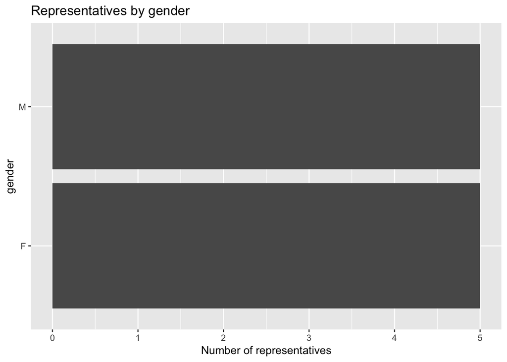

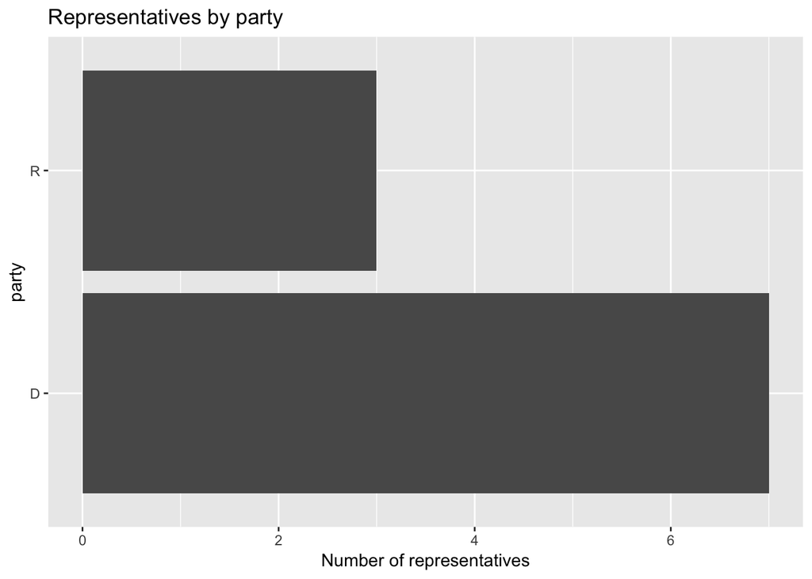

Lets take a closer look at one representative, Suzan DelBene. She is 57 years old, and you can find her on twitter at RepDelBene. Of the last 20 congressional votes she voted with the majority 100% of the time.